# Analyzing crimes in Seattle during the summer of 2014

**Author: Angel Perez Lemonche**

This notebook explores the crimes in Seattle during the summer of 2014. This is an assignment for the Coursera course *Communicating Data Science Results*.

The goal of this notebook is to tell a story from the data supported by visualizations. The visualizations have to be adequate, following the rules shown in the course. The conclusions here presented are not scientifically proven -there are merely based on observations of the data. This study cannot be used to support any fact outside the bounds of course.

This notebook can equally be used to explore the crimes in San Francisco, or other cities with similar input format, but the analysis presented in this notebook has been done using data from Seattle.

In this assignment, a possible response to the following questions is given:

1. When are the crimes more often reported? Which types of crimes occur more frequently given an hour of the day?
2. Where do the crimes typically occur? Is there any relationship between the location and the type of crime?

**Technical information**  
This assignment has been carried out using Python's *Jupyter Notebook* and the libraries *pandas* for data manipulation, *numpy* for numeric processing, *matplotlib* and *seaborn* for data visualization, and *folium* and *braca* for visualization in the map.

```python
# Toggle button to show/unshow the code

from IPython.display import HTML

# Hide the code
HTML('''<script>
code_show=true;
function code_toggle() {
 if (code_show){
 $('div.input').hide();
 } else {
 $('div.input').show();
 }
 code_show = !code_show
}
$( document ).ready(code_toggle);
</script>
<form action="javascript:code_toggle()"><input type="submit" value="Click here to toggle on/off the raw code."></form>''')
```

```python
# Import the libraries and definition of functions to use

import pandas as pd
import numpy as np

import matplotlib.pyplot as plt
import seaborn as sns

import folium
from folium import plugins
import branca

def plotCrimeByHour(df, min_plot = 100):
    ''' Plot the average reports by hour of the day and total reports by hour in 2014'''

    # Data processing
    df['Time'] = df.index.hour
    df['Time'] = df.apply(lambda x: x['Time']+24 if x['Time']<6 else x['Time'], axis = 1)
    df['Year'] = df.index.year
    df['Month'] = df.index.month
    df['Day'] = df.index.day
    df['DayYear'] = df.apply(lambda x: str(x['Year'])+'-'+str(x['Month'])+'-'+str(x['Day']), axis=1)
    df = df.drop(['Year', 'Month', 'Day', 'Location', 'Zone'], axis =1)

    # Plot average number of reports per hour
    fig, ax1= plt.subplots(figsize=(10,7))
    ax1.grid(True)
    ax2 = ax1.twinx()
    dfgroup = df[['Crime']].groupby([df['Time'], df['DayYear']]).count()
    dfgroup.reset_index(level=0, inplace = True)
    ax1.plot(dfgroup.groupby('Time').mean(), '--', linewidth = 5, alpha = .7)

    # Compute total police reports per hour
    crime = pd.DataFrame(df.groupby(['Time', 'Crime']).count())
    crime.reset_index(level=1, inplace=True)
    total = crime['DayYear'].groupby(crime.index).sum()
    crime.reset_index(inplace=True)
    crime['Total'] = crime['Time']
    crime['Total'] = crime['Total'].apply(lambda x: total.loc[x])
    crime['Ratio'] = crime['DayYear']
    crime = crime[crime['Ratio'] > min_plot]
    crime = crime.sort_values('Ratio', ascending = False)

    # Plot the scatterplot
    sns.scatterplot(data=crime, x='Time', y='Ratio', hue='Crime',s=200, alpha = .7, ax=ax2)

    # Add axis and labels
    ax1.set_xticks(range(6,30,3))
    ax1.set_xticklabels(['%02dh'%(3*x+6) if 3*x+6 <24 else '%02dh'%(3*x-18) for x in range(8)])
    ax1.set_ylabel('Average police reports per hour in the summer of 2014 (blue line)' )
    ax2.set_ylabel('Total police reports per hour in the summer of 2014 (dots)')
    ax1.set_title('Crime reports per hour')
    plt.legend(loc='upper left')


def plotMap(df, city_center, typeofmap = 'Zone', percentage = 1):
    '''Scatter plot on a map with layers'''
    top = 10
    colors = ['blue', 'orange', 'lightgreen', 'red', 'purple', 'pink', 'darkgreen', 'lightblue', 'darkred', 'black']

    top_values = df.groupby(typeofmap).count().sort_values(by='Location', ascending=False).iloc[0:top]['Location']
    top_list = list(top_values.index)
    color_dic = {top_list[x] : colors[x] for x in range(top)}

    top_values = top_values/len(df)
    m = folium.Map(location=city_center, tiles="OpenStreetMap", zoom_start=12, world_copy_jump=False, no_wrap=True)
    plugins.Fullscreen(position='topleft', force_separate_button=True).add_to(m)
    #plugins.ScrollZoomToggler().add_to(m)

    # Make groups of scatter points of crimes
    fg = folium.FeatureGroup('ALL')
    m.add_child(fg)

    # Loop over different types of crimes
    layer_dic = {}
    for typ in color_dic.keys():
        legend = typ+' (%.2f%%)'%(top_values[typ]*100)
        g = plugins.FeatureGroupSubGroup(fg, legend)
        m.add_child(g)
        layer_dic[typ] = g

    legend = 'OTHER (%.2f%%)'%((1-top_values.sum())*100)
    g = plugins.FeatureGroupSubGroup(fg, legend)
    m.add_child(g)
    layer_dic['OTHER'] = g

    # Make a layer control
    l = folium.LayerControl().add_to(m)

    # For over the points
    for x, new_df in enumerate(df.iterrows()):
        new_df = new_df[1]

        # Stop condition
        if x >= len(df)*percentage/100.0:
            break

        # Marker color and group
        try:
            marker_color = color_dic[new_df[typeofmap]]
            group = layer_dic[new_df[typeofmap]]
        except:
            marker_color = 'gray'
            group = layer_dic['OTHER']

        # Marker in the scatter map
        folium.CircleMarker(
            location=[new_df['x'], new_df['y']],
            popup=new_df['Crime']+' - ZONE '+str(new_df['Zone']),
            fill_color=marker_color,
            color='black',
            opacity=0.2,
            radius=7,
            fill_opacity = .8
        ).add_to(group)

    return m


def plotCrimeLocation(df, percentage = 1, seed = 100):
    '''Plot a cluster map of crimes or a map of zones and a map of types of crime'''

    df = df.sample(frac=1, random_state=seed)
    # Location to coordinates
    df['x'] = df.Location.apply(lambda x: float(x.split(', ')[0][1:]))
    df['y'] = df.Location.apply(lambda x: float(x.split(', ')[1][:-1]))
    df = df[df['x']> 0]

    city_center = (np.mean(df['x']), np.mean(df['y']))

    # Colors for different types of crime
    colors = ['blue', 'orange', 'lightgreen', 'red', 'purple', 'pink', 'darkgreen', 'lightblue', 'darkred', 'black']

    # Generate the maps
    mtype = plotMap(df, typeofmap = 'Crime', city_center=city_center, percentage=percentage)
    mzone = plotMap(df, typeofmap = 'Zone', city_center=city_center, percentage=percentage)

    # Plot the two maps
    f = branca.element.Figure()
    d1 = f.add_subplot(1, 2, 1).add_child(mzone)
    d2 = f.add_subplot(1, 2, 2).add_child(mtype)
    d1.get_root().html.add_child(folium.Element('<div><h4><center>Map of zones</div>'))
    d2.get_root().html.add_child(folium.Element('<div><h4><center>Map of types of crime</div>'))

    return f
```

### Choose the city to upload the data

```python
city = 'SEATTLE' # you can also try 'SAN FRANCISCO'.
print(city)


# Load and clean the dataset for the propuse of this assignment
if city == 'SEATTLE':
    dataset = pd.read_csv('seattle_incidents_summer_2014.csv', low_memory=False)[['Summarized Offense Description', 'Occurred Date or Date Range Start', 'District/Sector', 'Location']]
    dataset.columns = ['Crime', 'Date', 'Zone', 'Location']
    dataset['Date'] = pd.DatetimeIndex(pd.to_datetime(dataset['Date']).apply(lambda x: x.replace(minute=0)))
    dataset.set_index('Date', drop=True, inplace=True)

else:
    dataset = pd.read_csv('sanfrancisco_incidents_summer_2014.csv', low_memory=False)[['Category', 'Date', 'Time', 'PdDistrict', 'Location']]
    dataset.columns = ['Crime', 'Date', 'Time', 'Zone', 'Location']
    dataset['Date'] = pd.DatetimeIndex(pd.to_datetime(dataset['Date']+' '+dataset['Time']).apply(lambda x: x.replace(minute=0)))
    del dataset['Time']
    dataset.set_index('Date', drop=True, inplace=True)
```

```
SEATTLE
```

### Q1: When are the crimes more often reported?

Based on the figure below, we can tell by the blue line that the crimes happen more often during the evening, being less frequent between 3 am and 6 am. We can also observe two pronounced peaks at midday and midnight that exceed the expected distribution. A possible explanation to this effect is that when people are unsure on when a criminal act happened, when they reported it they say 'around midday' or 'around midnight'. The maximum average number of reports happens at midnight (22.5) and the minimum at 5 am (5).

Taking a look at the dots (using the right axis) we can see that 'car prowl' is the most reported crime in Seattle, and occurs more frequently between 4 pm and 3 am, with a maximum at 10 pm. 'Vehicle theft' crime outstand in the second position between 8 pm and 10 pm. 'Burglary' reports are more frequent at 12 pm, 5 pm and 12 am. Again, a possible explanation of this is that people report that a burglary crime happened at midday, at 5 pm (when they return to work) or at midnight when they are unsure about it. 'Assaults' happen more often between 9 pm and 1 am.

The most reported crime is 'car prowl', with more than 500 reports at 10 pm during the summer of 2014. The second more reported crime is 'vehicle theft' with more than 300 reports at 9 pm during the summer of 2014.

So if you want to visit Seattle, be sure you lock your car correctly and park it safely during the evenings.

**As an evaluator you may wonder:**

- *Why the x axis starts at 6 am?*
  - I thought it was reasonable to start the plot where day starts for workers. This way is easier to see the outlier at 12 am.
- *Why don't you plot all crimes?*
  - I thought that too many points and types of crime will distract the reader from what I intend to show. This way I pay attention to significant or more frequent types of crime.
- *Why do you use the total number of police reports and not the percentage per hour?*
  - I think this way it's easier to see the tendency of the crimes along the day than using percentages.

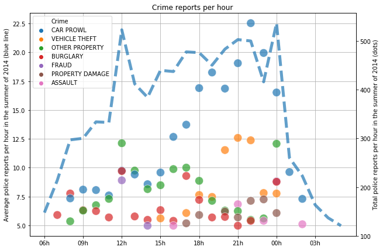

```python
# Select the dataset and the minimum number of reports per hour to to plot.
plotCrimeByHour(dataset, min_plot=120)
```

### Q2: Where do the crimes typically occur?

Exploring the **map of zones** (on the left) we can observe that 15.41 % of the crimes are located in the areas K (in orange) and M (in blue), corresponding with the city center. Other clusters of crimes can be located in the south of Capitol Hill (zones E, in purple, and C, in gray), in the university area (zone U, in green), and all along Aurora Avenue North (zone N, in red). It is not clear to me how the zones B (light green) and J (pink) are separated. On the other hand, more secure zones are Magnolia (west), West Seatle (southwest) and the northeast, and the southeast (from Madison Park to Madrona) due to the absence of crime points.

Playing with the layers of the **map of types of crime** (on the right), we can observe that the most frequent type of crime (19.13 %) is 'car prowl' (in blue), as we already knew from the previous graph. Despite this crime happens all around the city, it is generally located in the city center; as well as crimes of 'other property' (in orange, 11.45 % of all crimes). On the other hand, 'burglary' (in light green, 9.77 % of all the crimes reported) and 'vehicle theft' (in red, 9.34 %) are more spread around all the city, not that centrally located. This might be because, in order to break into a house or a car the criminal must be unseen, so it cannot be done in populated areas. If we go along Aurora Avenue North, we can spot various cases of 'prostitution' along that street.

**As an evaluator you may wonder:**

- *Why do you only plot a percentage of the samples and not all of them?*
  - Again, this is a problem of visualization. If I plot all the samples it's difficult to see tendencies, because we would have a big cloud of points.
- *Why don't you use more colors (like a palette of continuous colors) to plot other kind of crimes or zones?*
  - As we saw in the course, human eyes don't make such a big distinction between colors. That's why I'm focusing on the top 10 characteristics (zones or types of crime) and I group the rest all together.
- *Why isn't a legend for the colors?*
  - Actually it is! On the top right corner you can change the layers of the map, and check and uncheck whatever you want. I encourage you to play with the interactive map to see the tendencies that I analyze on the text.

```python
# Select the dataset and the percentage of samples to be displayed
plotCrimeLocation(dataset, percentage=2)
```

[interactive chart not shown]

### Conclusions

- We have seen that crimes typically occur in the evening, close to the city center. We have located a few neighborhoods where the crime was more frequent during the summer of 2014 in Seattle, and some others where crime is rare.
- Main crimes reported are located in the city center, such as 'car prowl' (19.13 %) that frequently happens during the evening and night, and 'other property' (11.45 %) that happens along the morning and afternoon.
- Crimes that are more spread around the city are 'burglary' (9.77 %) that frequently happens during the morning and afternoon, and 'vehicle theft' (9.34 %) that happens in the evening and night.